# Data_Analyst_ND_Project1

#### What is our independent variable? What is our dependent variable?

Our independent variable is color of word. Our dependent variable is time it takes to name the ink color.

#### What is an appropriate set of hypotheses for this task? What kind of statistical test do you expect to perform? Justify your choices.

H_0 is that μC=μI which means that average of response times for population of congruent and incongruent words will be the same after perfoming test.

H_1 is that μC!=μI which means that average of response times for population of congruent and incongruent words will be different after perfoming test.

I've chosen these hypothesis because we're going to check if we can reject first one in favour of second one. I've also chosen H_1 like this(two-tailed) because I'd like to know if there is significat difference between response times in any direction.

I'm going to perform a T-test because we know only sample parameters. I've also chosen dependent sample test because single person responded in both groups- congruent and incongruent.

#### Report some descriptive statistics regarding this dataset.

```python
import pandas as pd
path = r'~/Pobrane/stroopdata.csv'
dataFrame = pd.read_csv(path)
dataFrame.head()
```

|  | Congruent | Incongruent |
| --- | --- | --- |
| 0 | 12.079 | 19.278 |
| 1 | 16.791 | 18.741 |
| 2 | 9.564 | 21.214 |
| 3 | 8.630 | 15.687 |
| 4 | 14.669 | 22.803 |

```python
mean_congruent = dataFrame['Congruent'].mean()
mean_incongruent = dataFrame['Incongruent'].mean()
median_congruent = dataFrame['Congruent'].median()
median_incongruent = dataFrame['Incongruent'].median()
print "Mean for congruent words:", mean_congruent
print "Mean for incongruent words:", mean_incongruent
print "Median for congruent words:", median_congruent
print "Median for incongruent words:", median_incongruent
```

```
Mean for congruent words: 14.051125
Mean for incongruent words: 22.0159166667
Median for congruent words: 14.3565
Median for incongruent words: 21.0175
```

```python
variance_congruent = dataFrame['Congruent'].var()
variance_incongruent = dataFrame['Incongruent'].var()
print "Variance for congruent words:", variance_congruent
print "Variance for incongruent words:", variance_incongruent
```

```
Variance for congruent words: 12.6690290707
Variance for incongruent words: 23.0117570362
```

```python
stdev_congruent = dataFrame['Congruent'].std()
stdev_incongruent = dataFrame['Incongruent'].std()
print "Standard sample deviation for congruent words:", stdev_congruent
print "Standard sample deviation for incongruent words:", stdev_incongruent
```

```
Standard sample deviation for congruent words: 3.55935795765
Standard sample deviation for incongruent words: 4.79705712247
```

#### Provide one or two visualizations that show the distribution of the sample data.

```python
%matplotlib inline
import matplotlib.pyplot as plt
```

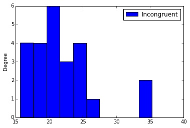

```python
dataFrame.plot(x='Congruent', kind='hist')
```

Our sample is really small but if I would have to say something about this plot, I would say that it's positively skewed.

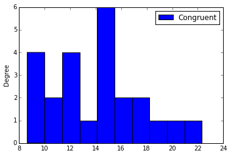

```python
dataFrame.plot(x='Incongruent', kind='hist')
```

#### Now, perform the statistical test and report your results. What is your confidence level and your critical statistic value?

```python
import math
sample_size=len(dataFrame)
mean_difference = mean_congruent - mean_incongruent
standard_deviation = dataFrame.apply(lambda row: row['Congruent'] - row['Incongruent'], axis=1).std()
t_score = mean_difference/(standard_deviation/math.sqrt(sample_size))
critical_value = 3.845
confidence_level = '.001'
```

```python
print "T-score is", t_score
if critical_value < abs(t_score):
    print "We reject H0 with confidence level %s" % confidence_level
else:
    print "We can't reject H0 with confidence level %s" % confidence_level
```

```
T-score is -8.02070694411
We reject H0 with confidence level .001
```

Our T-score is really high so I reject null hypothesis with confidence level of more than 99.9%. My conclusion is that statistically we can say that response times for incongruent words are higher than congruent words. Result of experiment match up with my expectations- however the T-score is higher than I expected.